# Despacho de Energía Eléctrica

Análisis Despacho de Energía Eléctrica en Colombia

Abraham García

2025-05-13

Este informe analiza el comportamiento del despacho de energía eléctrica en Colombia durante el año **2024**. A continuación, se presenta un análisis descriptivo de las siguientes variables:

- Demanda [GWh/día]
- Aportes Hidrológicos [GWh/día]
- Nivel de Embalses [GWh]
- Despacho de energía eléctrica [GWh/día]
- Precio de bolsa [COP/kWh]

A lo largo del presente informe se utilizarán dos conjuntos de datos. El primero contiene información del despacho diario clasificada por tipo de tecnología (Agua, Carbón, Gas, Líquidos, Menores y Sol), y será referido en adelante como `Dataset de Despacho`. El segundo conjunto incluye datos diarios de variables como la demanda, los aportes hidrológicos, el estado de los embalses y el precio de bolsa, y será referido como `Variables del Despacho`.

**Nota**: ✅ No hay duplicados en los Dataset.

# Análisis Descriptivo

A continuación, se presenta un análisis de frecuencia para cada una de las variables categóricas contenidas en los conjuntos de datos `Despacho de Energía` y `Variables del Despacho`.

## Registros de despacho por tipo de tecnología

En este caso, se espera que cada categoría contenga un total de registros equivalente al número de días del año 2024, es decir, 366 días.

Cantidad de registros por tipo de tecnologia

| Tecnologia | Cantidad de Registros |
| --- | --- |
| Agua | 366 |
| Carbon | 366 |
| Gas | 366 |
| Liquidos | 366 |
| Menores | 366 |
| Sol | 366 |

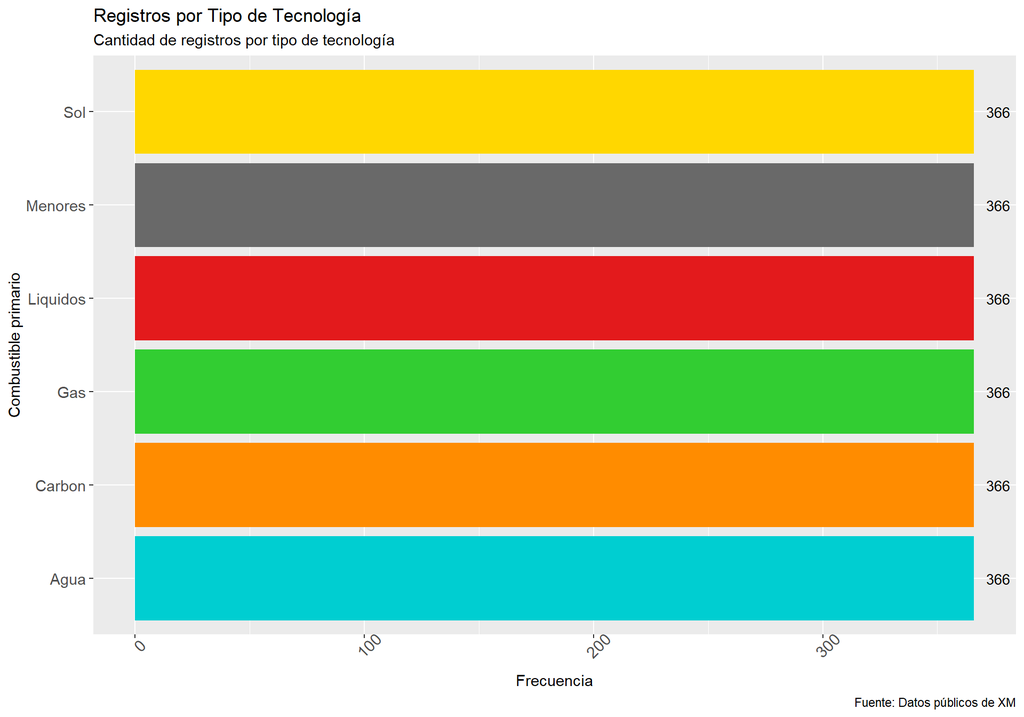

## Registros de despacho por día de la semana

En cuanto a los días de la semana, la cantidad de registros debería coincidir con la frecuencia con la que cada día ocurre a lo largo del año. Por lo general, cada día de la semana aparece entre 52 y 53 veces en un año, dependiendo de si el año es común o bisiesto.

Cantidad de registros por día de la semana

| Día de la Semana | Cantidad de Registros |
| --- | --- |
| domingo | 52 |
| lunes | 53 |
| martes | 53 |
| miércoles | 52 |
| jueves | 52 |
| viernes | 52 |
| sábado | 52 |

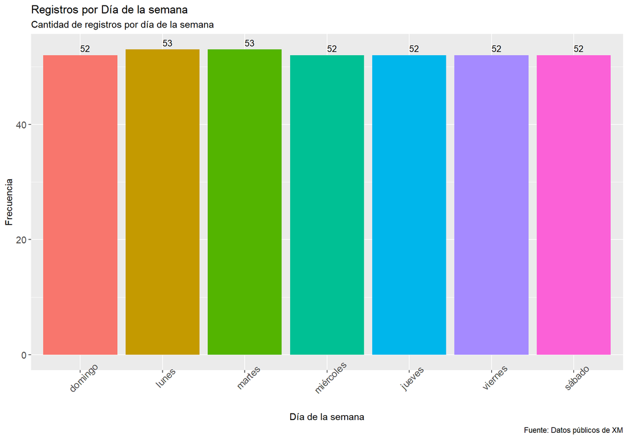

## Registros de despacho por día festivo

En la tabla de registros y en la gráfica de frecuencia se observa que, para el año 2024, hubo un total de 348 días normales y 18 días festivos.

Cantidad de registros por día festivo

| Festivo | Cantidad de Registros |
| --- | --- |
| Festivo | 18 |
| Normal | 348 |

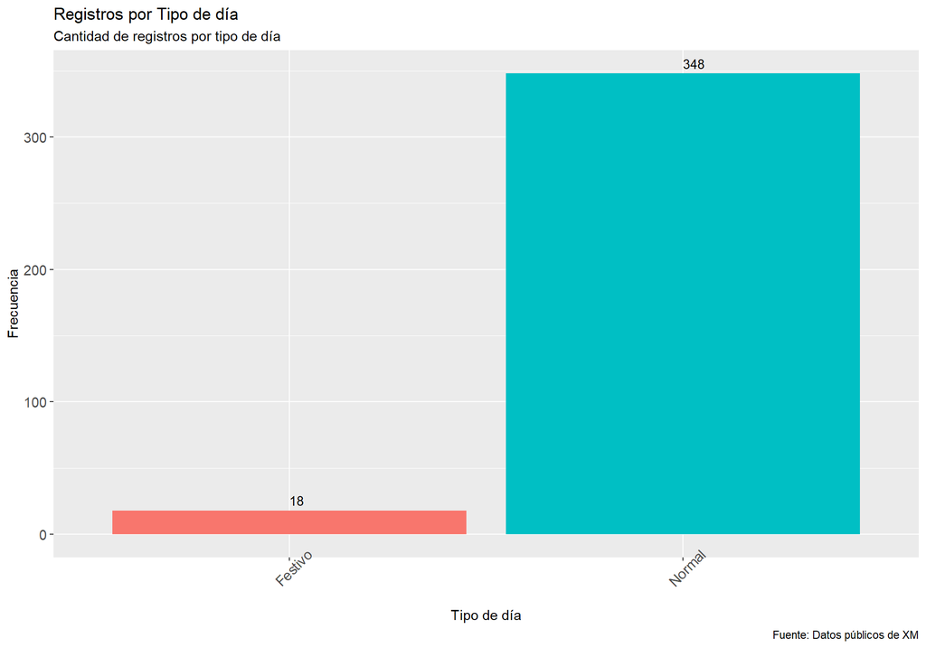

## Demanda promedio diaria por día de la semana y tipo de día

En relación con la demanda, se observa que en promedio el día festivo con mayor valor corresponde al domingo y el de menor valor al viernes. En contraste, para los días normales, el viernes presenta el mayor promedio de demanda, mientras que el domingo registra el menor.

Promedio Demanda por día de la semana y tipo de día

| Día semana | Festivo | Normal |
| --- | --- | --- |
| domingo | 211.47 | 202.19 |
| lunes | 199.60 | 229.63 |
| martes |  | 230.36 |
| miércoles | 209.05 | 231.48 |
| jueves | 205.03 | 231.80 |
| viernes | 195.95 | 231.94 |
| sábado | 211.39 | 220.22 |

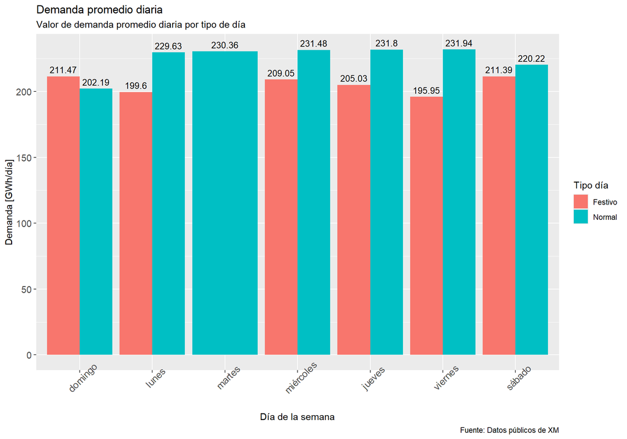

## Generación promedio diaria por día de la semana y tipo de tecnología

A continuación, se presenta la generación promedio diaria de energía en Colombia para el año 2024, desagregada por día de la semana y tipo de tecnología utilizada en el despacho eléctrico. Esta información permite identificar patrones de comportamiento en la participación de distintas fuentes como agua, gas, carbón, líquidos, fuentes menores y solar a lo largo de la semana. En estos elementos destaca la significativa contribución de los recursos con *Agua* como fuente primaria de energía, alcanzando promedios de generación de hasta 137.6 GWh/día.

Promedio Generación por día de la semana y tipo de tecnología

| Día semana | Agua | Carbon | Gas | Liquidos | Menores | Sol |
| --- | --- | --- | --- | --- | --- | --- |
| domingo | 116.04 | 21.24 | 32.64 | 1.99 | 20.31 | 6.58 |
| lunes | 131.44 | 22.12 | 37.42 | 2.11 | 20.47 | 6.59 |
| martes | 136.79 | 22.36 | 38.22 | 2.18 | 20.47 | 6.64 |
| miércoles | 135.44 | 22.90 | 39.39 | 2.35 | 20.33 | 6.62 |
| jueves | 136.46 | 22.90 | 39.73 | 2.28 | 20.18 | 6.67 |
| viernes | 137.60 | 22.35 | 39.03 | 2.32 | 20.28 | 6.56 |
| sábado | 128.21 | 22.28 | 37.26 | 2.05 | 20.32 | 6.68 |

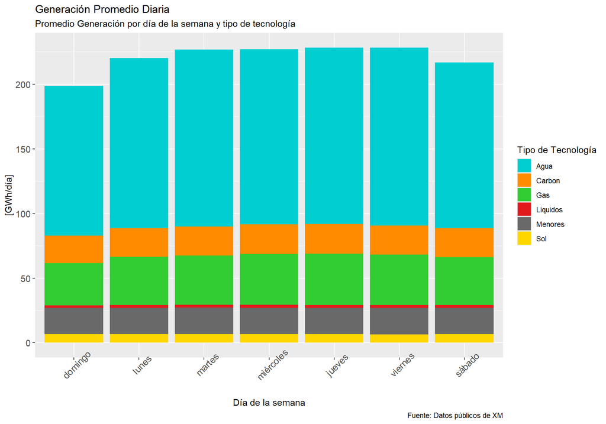

## Despacho por tecnología

En la siguiente gráfica se presenta el despacho diario de energía, desglosado por tipo de tecnología disponible en la matriz energética colombiana.

[interactive chart not shown]

## Generación hídrica versús térmica

En la siguiente gráfica se muestra la evolución de la generación hídrica y térmica a lo largo del año 2024.

**Nota**: Dar `play` o utilizar la barra para observar la evolución en el tiempo.

[interactive chart not shown]

## Precio de bolsa

El siguiente gráfico muestra la evolución del precio de bolsa diario a lo largo del año. Se observa un comportamiento con valores mínimos que descienden hasta 89.47 COP/kWh y picos máximos que alcanzan los 7233.16 COP/kWh.

[interactive chart not shown]

# Más allá de lo Descriptivo

A continuación, se presenta un análisis de la demanda promedio diaria del Sistema Interconectado Nacional, con el objetivo de caracterizar su comportamiento a lo largo del tiempo durante el año 2024.

## Tabla de medidas resumen para la demanda diaria

En la siguiente tabla se presentan las principales medidas resumen de la demanda diaria, incluyendo estadísticos como la media, mediana, desviación estándar, cuartiles y el rango intercuartílico, que permiten tener una visión general del comportamiento central y la dispersión de la variable.

Tabla de medidas resumen para la Demanda Diaria

| diaSemana | Cuenta | Promedio | Desvest | Varianza | CV | Q1 | Mediana | Q3 | RIC | Ext_inf | Ext_sup |
| --- | --- | --- | --- | --- | --- | --- | --- | --- | --- | --- | --- |
| domingo | 52 | 202.3700 | 5.851028 | 34.23453 | 0.02891253 | 198.2950 | 200.935 | 206.7675 | 8.4725 | 185.5863 | 219.4762 |
| lunes | 53 | 223.3987 | 13.910990 | 193.51565 | 0.06226980 | 220.5100 | 227.060 | 232.9500 | 12.4400 | 201.8500 | 251.6100 |
| martes | 53 | 230.3560 | 7.810903 | 61.01021 | 0.03390796 | 225.5300 | 230.420 | 236.1700 | 10.6400 | 209.5700 | 252.1300 |
| miércoles | 52 | 230.1846 | 8.745433 | 76.48259 | 0.03799312 | 226.0725 | 229.905 | 236.6350 | 10.5625 | 210.2287 | 252.4787 |
| jueves | 52 | 231.2813 | 7.161606 | 51.28860 | 0.03096491 | 226.6850 | 231.185 | 237.0625 | 10.3775 | 211.1187 | 252.6288 |
| viernes | 52 | 231.2498 | 7.873807 | 61.99683 | 0.03404892 | 226.8875 | 231.400 | 237.2125 | 10.3250 | 211.4000 | 252.7000 |
| sábado | 52 | 220.0481 | 6.175772 | 38.14016 | 0.02806556 | 215.7900 | 220.350 | 224.3450 | 8.5550 | 202.9575 | 237.1775 |

A partir de la tabla de medidas resumen se observa que el día con mayor demanda promedio es el jueves, alcanzando un valor de 231.28 GWh/día. En contraste, el lunes presenta la mayor variabilidad en la demanda diaria, con una desviación estándar de 13.91 y una varianza de 193.52.

## Tabla de frecuencias

La siguiente tabla muestra la distribución de frecuencias de la demanda diaria, agrupando los datos en intervalos para facilitar la identificación de patrones, concentraciones y posibles asimetrías en la distribución.

Tabla de Frecuencia para la Demanda Diaria

| Demanda | Frecuencia | Frecuencia Relativa | Frecuencia Acumulada Absoluta | Frecuencia Acumulada | Frecuencia Absoluta |
| --- | --- | --- | --- | --- | --- |
| 179 | 1 | 0.3% | 1 | 0.27% | 1 |
| 189 | 1 | 0.3% | 2 | 0.55% | 1 |
| 190 | 1 | 0.3% | 3 | 0.82% | 1 |
| 194 | 4 | 1.1% | 7 | 1.91% | 4 |
| 195 | 1 | 0.3% | 8 | 2.19% | 1 |
| 196 | 2 | 0.5% | 10 | 2.73% | 2 |
| 197 | 2 | 0.5% | 12 | 3.28% | 2 |
| 198 | 7 | 1.9% | 19 | 5.19% | 7 |
| 199 | 7 | 1.9% | 26 | 7.10% | 7 |
| 200 | 5 | 1.4% | 31 | 8.47% | 5 |
| 201 | 6 | 1.6% | 37 | 10.11% | 6 |
| 202 | 3 | 0.8% | 40 | 10.93% | 3 |
| 203 | 2 | 0.5% | 42 | 11.48% | 2 |
| 205 | 5 | 1.4% | 47 | 12.84% | 5 |
| 206 | 3 | 0.8% | 50 | 13.66% | 3 |
| 207 | 4 | 1.1% | 54 | 14.75% | 4 |
| 208 | 2 | 0.5% | 56 | 15.30% | 2 |
| 209 | 5 | 1.4% | 61 | 16.67% | 5 |
| 210 | 4 | 1.1% | 65 | 17.76% | 4 |
| 211 | 4 | 1.1% | 69 | 18.85% | 4 |
| 212 | 1 | 0.3% | 70 | 19.13% | 1 |
| 213 | 5 | 1.4% | 75 | 20.49% | 5 |
| 214 | 7 | 1.9% | 82 | 22.40% | 7 |
| 215 | 4 | 1.1% | 86 | 23.50% | 4 |
| 216 | 4 | 1.1% | 90 | 24.59% | 4 |
| 217 | 3 | 0.8% | 93 | 25.41% | 3 |
| 218 | 1 | 0.3% | 94 | 25.68% | 1 |
| 219 | 4 | 1.1% | 98 | 26.78% | 4 |
| 220 | 6 | 1.6% | 104 | 28.42% | 6 |
| 221 | 8 | 2.2% | 112 | 30.60% | 8 |
| 222 | 5 | 1.4% | 117 | 31.97% | 5 |
| 223 | 11 | 3.0% | 128 | 34.97% | 11 |
| 224 | 19 | 5.2% | 147 | 40.16% | 19 |
| 225 | 12 | 3.3% | 159 | 43.44% | 12 |
| 226 | 13 | 3.6% | 172 | 46.99% | 13 |
| 227 | 17 | 4.6% | 189 | 51.64% | 17 |
| 228 | 21 | 5.7% | 210 | 57.38% | 21 |
| 229 | 14 | 3.8% | 224 | 61.20% | 14 |
| 230 | 19 | 5.2% | 243 | 66.39% | 19 |
| 231 | 10 | 2.7% | 253 | 69.13% | 10 |
| 232 | 9 | 2.5% | 262 | 71.58% | 9 |
| 233 | 10 | 2.7% | 272 | 74.32% | 10 |
| 234 | 8 | 2.2% | 280 | 76.50% | 8 |
| 235 | 10 | 2.7% | 290 | 79.23% | 10 |
| 236 | 14 | 3.8% | 304 | 83.06% | 14 |
| 237 | 14 | 3.8% | 318 | 86.89% | 14 |
| 238 | 13 | 3.6% | 331 | 90.44% | 13 |
| 239 | 9 | 2.5% | 340 | 92.90% | 9 |
| 240 | 7 | 1.9% | 347 | 94.81% | 7 |
| 241 | 9 | 2.5% | 356 | 97.27% | 9 |
| 242 | 4 | 1.1% | 360 | 98.36% | 4 |
| 243 | 2 | 0.5% | 362 | 98.91% | 2 |
| 244 | 3 | 0.8% | 365 | 99.73% | 3 |
| 246 | 1 | 0.3% | 366 | 100.00% | 1 |

## Distribución de los datos de demanda diaria

### Gráfica de distribución empírica

En la siguiente gráfica se presenta la distribución empírica acumulada de la demanda diaria, lo que permite visualizar cómo se acumulan los valores a lo largo del rango observado, facilitando comparaciones con distribuciones teóricas.

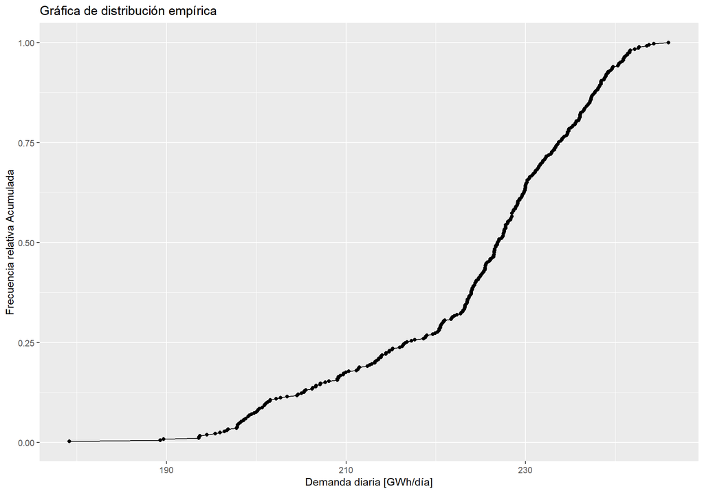

### Histograma

El siguiente histograma muestra la frecuencia de ocurrencia de distintos rangos de valores de la demanda diaria. Esta visualización permite identificar la forma de la distribución, así como detectar sesgos, asimetrías o presencia de valores atípicos.

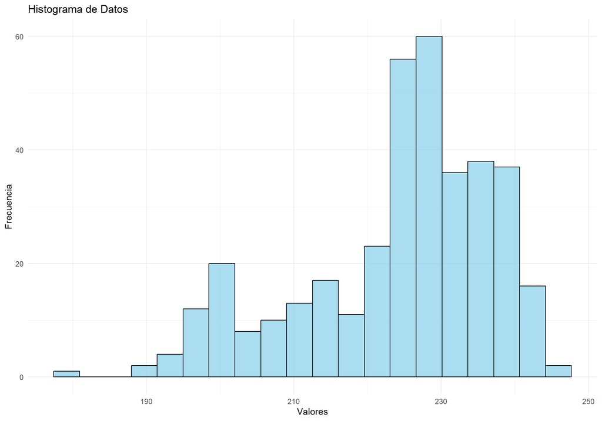

### Gráfico de densidad

El gráfico de densidad que se muestra a continuación representa una estimación suave de la distribución de la demanda diaria, proporcionando una alternativa al histograma para observar la forma y concentración de los datos.

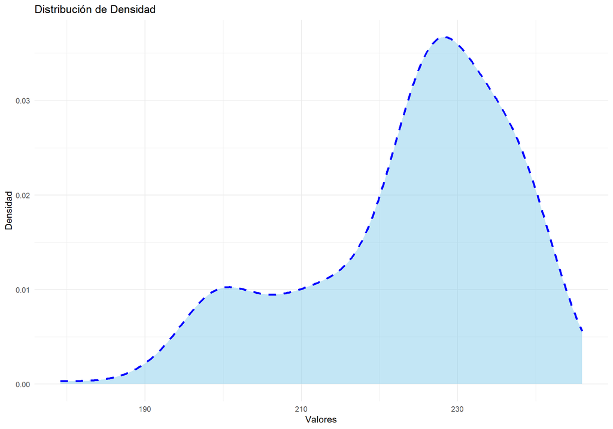

## Comprobación de normalidad

La siguiente sección incluye pruebas para evaluar si la distribución de la demanda diaria se ajusta a una distribución normal, lo cual es fundamental para la aplicación de ciertos métodos estadísticos.

### Prueba de normalidad de Lilliefors

El valor p de la prueba de normalidad de Lilliefors es 3.8067374^{-19}, lo que indica que NO se puede asumir normalidad.

### Prueba de normalidad de Shapiro-Wilk

El valor p de la prueba de normalidad de Shapiro-Wilk es 2.1209831^{-12}, lo que indica que NO se puede asumir normalidad.

## Cálculo de intervalo de confianza

A continuación, se presenta el cálculo del intervalo de confianza para la media de la demanda diaria, proporcionando una estimación del rango dentro del cual se espera que se encuentre el valor promedio verdadero con un nivel de confianza especificado.

El intervalo de confianza al 95% para la demanda diaria en días normales es de 223.98 a 226.54 GWh/día.

En días festivos, es de 197.93 a 207.25 GWh/día.

# Conclusiones

- En este informe se automatiza el análisis descriptivo y algunos aspectos de inferencia estadística sobre los datos del despacho eléctrico en Colombia. El análisis de la demanda y generación de energía en el Sistema Interconectado Nacional permite identificar comportamientos relevantes a lo largo de los días de la semana y los meses del año. Se evidencia los días que presentan los mayores niveles de generación y demanda promedio diaria, como también los días con una disminución significativa en estas variables, lo que sugiere una estrecha relación con los ciclos de actividad económica. Asimismo, se destaca el predominio de las tecnologías hídricas en la matriz energética del país, consolidándolas como la principal fuente de generación eléctrica.
- Este ejercicio resalta la utilidad de automatizar informes con RMarkdown, permitiendo generar reportes reproducibles y eficientes para análisis periódicos o regulatorios. Por otra parte, a lo largo del documento se aplicaron herramientas fundamentales de análisis estadístico descriptivo e inferencial que resultaron clave para interpretar el comportamiento de la demanda energética. La construcción de medidas resumen, la exploración de distribuciones mediante gráficos y pruebas de normalidad, así como el cálculo de intervalos de confianza, facilitaron una comprensión más profunda de la variabilidad y tendencia central de los datos. Estos procedimientos no solo fortalecen la interpretación cuantitativa de fenómenos energéticos, sino que también demuestran la importancia de la estadística como una disciplina esencial para el análisis riguroso y la toma de decisiones informadas.